# Bayes factor tutorial

# 1 A little tutorial on the Bayes factor

In this notebook, we try to deepen the understanding of what a Bayes factor is and how it is computed.

**Our goal**: To test whether a coin is fair or not by computing a Bayes factor.

**Procedure**: We flipped the coin 10 times and it came up heads 9 times.

**Model 0 ($H_{0}$)**: The coin is fair ($\theta = 0.5$)

**Model 1 ($H_{1}$)**: The coin is not fair ($\theta \neq 0.5$)

## 1.1 Bayes formula

The bayes formulas for both models can be written as:

$$p(M1|D) = \frac{p(M1)p(D|M1)}{p(D)}$$

Where

- $p(M1|D)$ is the posterior probability of Model 1 given the data.
- $p(M1)$ is the prior probability of Model 1 before seeing any data.
- $p(D|M1)$ is the probability of the data given that Model 1 is true.
- $p(D)$ is the marginal likelihood.

and

$$p(M0|D) = \frac{p(M0)p(D|M0)}{p(D)}$$

## 1.2 Marginal Likelihood

$p(D)$ is an average likelihood where we compute the likelihood for each model under consideration weighted by the probability of that model and sum everything up. Therefore, $p(D)$ can also be written as:

$$p(D) = p(M1)p(D|M1) + p(M0)p(D|M0)$$

## 1.3 The Bayes factor

Let’s rearrange both formulas above to get a ratio of posterior model probabilities.

$$\frac{p(M1|D)}{p(M0|D)} = \frac{p(M1)}{p(M0)}\frac{p(D|M1)}{p(D|M0)}$$

where

- $\frac{p(M1|D)}{p(M0|D)}$ is the ratio of posterior model probabilities given the data.
- $\frac{p(M1)}{p(M0)}$ is the ratio of prior model probabilities.
- $\frac{p(D|M1)}{p(D|M0)}$ is the updating factor, also called **Bayes factor**.

## 1.4 Computing the Bayes factor

### 1.4.1 Model 0 ($H_{0}$)

We start with Model 0 ($H_{0}$).

Our prior assumption about the coin was that it is a fair coin, so $p(\theta|M0)$ = 0.5

If we write $p(D|M0) out, we get:

$$p(D|M0) = \int_{0}^{1}p(D|M0,\theta)p(\theta|M0)$$

This means that we have to compute the likelihood for each possible value of $\theta$. Here, our prior distribution is a point hypothesis so we only assume one value of $\theta$, namely 0.5.

The likelihood function for the coin-toss example is:

$$p(d|M0,\theta) = \binom{n}{k} \cdot \theta^k(1-\theta)^{n-k}$$

If we plug our data and the value for $\theta$ in, we get:

$$p(d|M0,\theta) = \binom{10}{9} \cdot 0.5^9(0.5)^{1} = 0.0097$$

```r
binom_lik = function(theta) return(choose(10,9) * theta^9 * (1-theta)^1)
(ml_m0 = binom_lik(0.5))
```

```
[1] 0.009765625
```

### 1.4.2 Model 1 ($H_{1}$)

Our prior assumption about the coin was that it is not! a fair coin, so our prior beliefs might be captured via a beta distribution:

$$p(\theta) = beta(2,2)$$

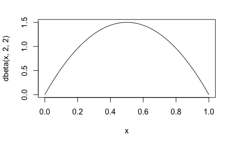

We can compute the marginal likelihood $p(D|M1)$ by sampling multiple values from this prior distribution and plugging those sampled values in the likelihood function.

```r
ml_sum = 0
N = 100000
for(i in 1:N){
  theta = rbeta(n = 1, 2, 2)
  ml_sum = ml_sum + binom_lik(theta)
}
(ml_m1 = ml_sum/N)
```

```
[1] 0.0702591
```

All that is left to do is compute the actual Bayes factor:

```r
(BF10 = ml_m1 / ml_m0)
```

```
[1] 7.194532
```

## 1.5 Savage-Dickey Density Ratio

There is another simple way to get Bayes factors for nested model comparisons where one model fixes the parameter at a prespecified value, the so called Savage-Dickey method.

The Savage-Dickey method simply states that one can compare the height of the posterior distribution with the height of the prior distribution at the parameter value of interest.

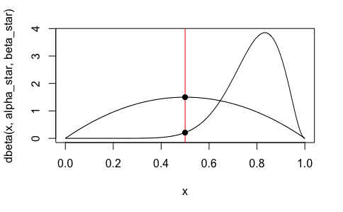

The ratio of the two values is the Bayes factor

```r
density_prior = dbeta(0.5,alpha,beta)
density_post = dbeta(0.5,alpha_star,beta_star)
(BF10 = density_prior/density_post)
```

```
[1] 7.160839
```